# Question

Let’s consider an alternative way to multiply 96 and 78.

First, let’s break each number into its tens and ones.

$$96 ~~=~~ 90+6$$
$$78 ~~=~~ 70+8$$

Now, find all 4 indicated products. Also, find the totals.

| * | $90$ | $6$ | **total** |
| --- | --- | --- | --- |
| $70$ | ##ANSWER1## | ##ANSWER2## | ##ANSWER5## |
| $8$ | ##ANSWER3## | ##ANSWER4## | ##ANSWER6## |
| **total** | ##ANSWER7## | ##ANSWER8## | ##ANSWER9## |

## Answerlist

- 63
- 630
- 6300
- 63000
- 42
- 420
- 4200
- 42000
- 72
- 720
- 7200
- 72000
- 48
- 480
- 4800
- 48000
- 468
- 768
- 6720
- 7020
- 7488
- 468
- 768
- 6720
- 7020
- 7488
- 468
- 768
- 6720
- 7020
- 7488
- 468
- 768
- 6720
- 7020
- 7488
- 468
- 768
- 6720
- 7020
- 7488

# Solution

$$96\cdot 78 = 7488$$

| * | $90$ | $6$ | **total** |
| --- | --- | --- | --- |
| $70$ | 6300 | 420 | 6720 |
| $8$ | 720 | 48 | 768 |
| **total** | 7020 | 468 | 7488 |

At some point I learned about the [multiplication by lines](https://www.mathnstuff.com/math/spoken/here/2class/60/bylines.htm) method. You’ll notice there are 9 lines above 6 lines, both with positive slope. There are also 7 lines above 8 lines, both with negative slope. The number of intersections in the four corners are found with multiplication: $9\cdot7=63$ and $6\cdot7=42$ and $9\cdot8=72$ and $6\cdot8=48$.

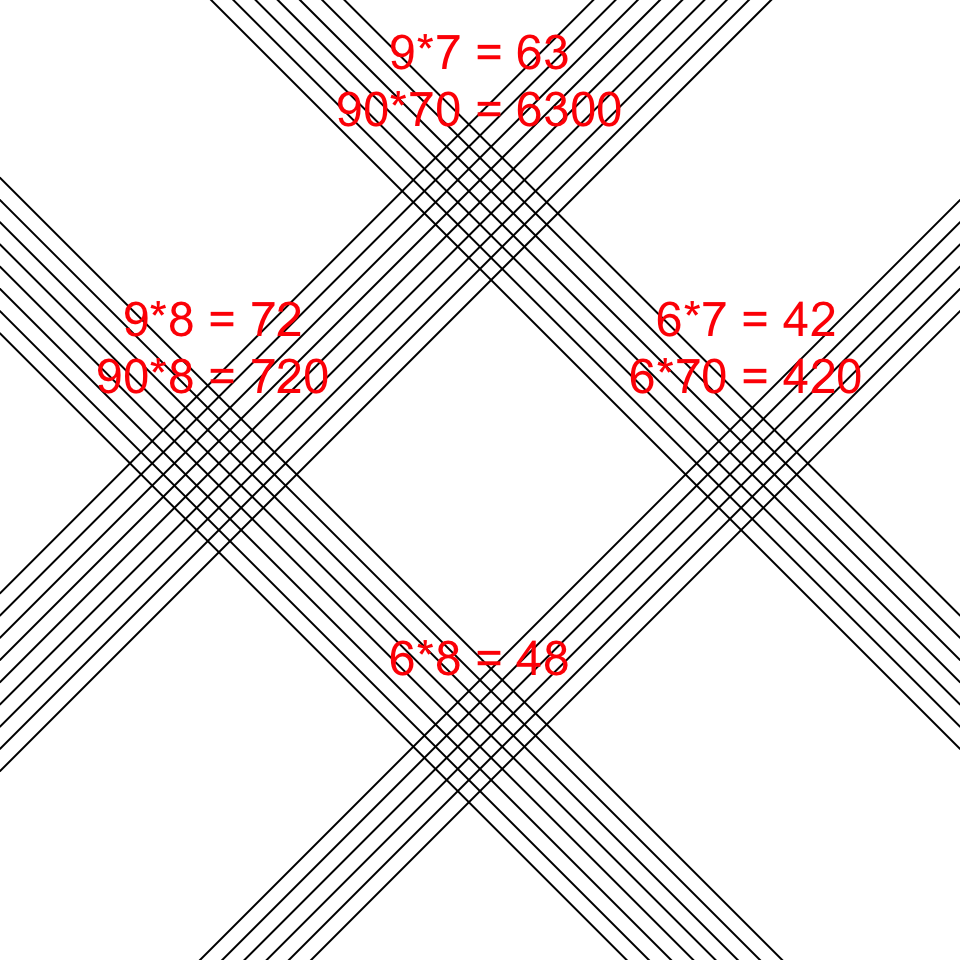

$$6300 + 420 + 720 + 48 ~~=~~
7488$$

# Meta-information

extype: cloze exclozetype: schoice|schoice|schoice|schoice|schoice|schoice|schoice|schoice|schoice exsolution: 0010|0100|0100|1000|00100|01000|00010|10000|00001 exname: multiply_2digits